# Examples Using the rms Package

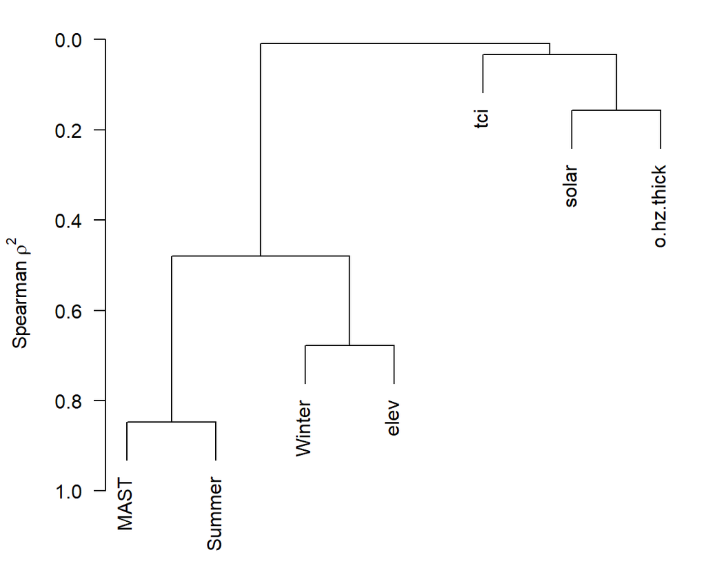

```r
vc <- varclus(as.matrix(m[, vars]), similarity = 'spearman', method='complete')

par(mar=c(1,4.5,1,1), las=1)
plot(vc)
```

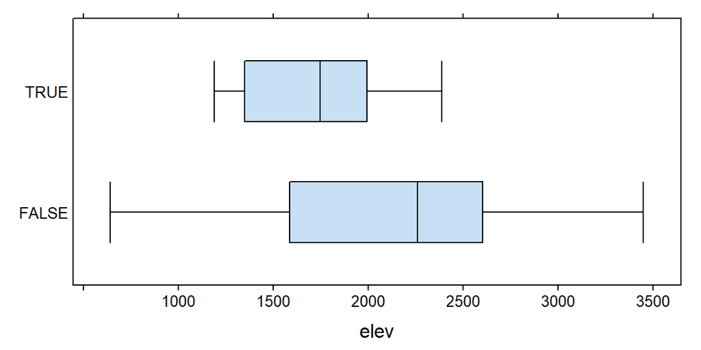

```r
# O horizon presence vs. other vars
bwplot(o.hz ~ elev, data=m, par.settings=tactile::tactile.theme())
```

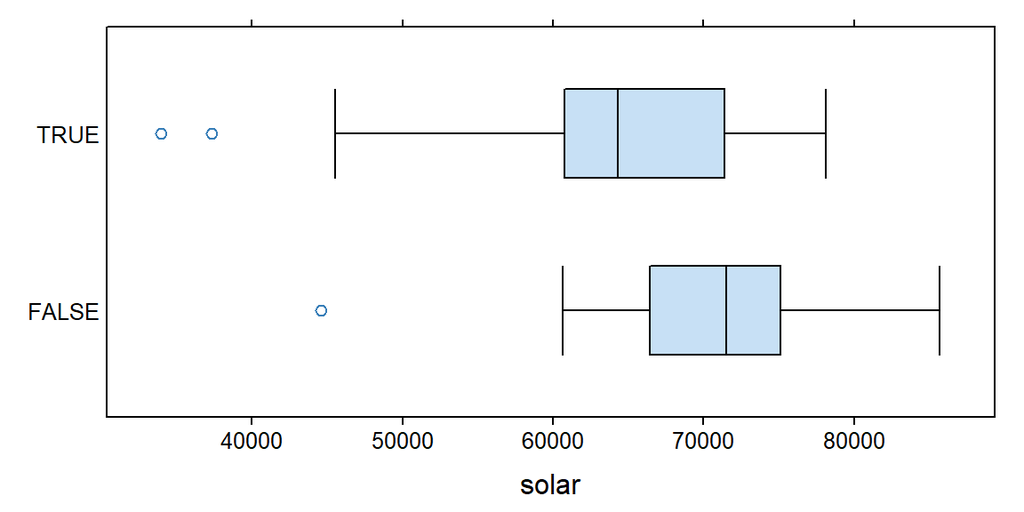

```r
bwplot(o.hz ~ solar, data=m, par.settings=tactile::tactile.theme())
```

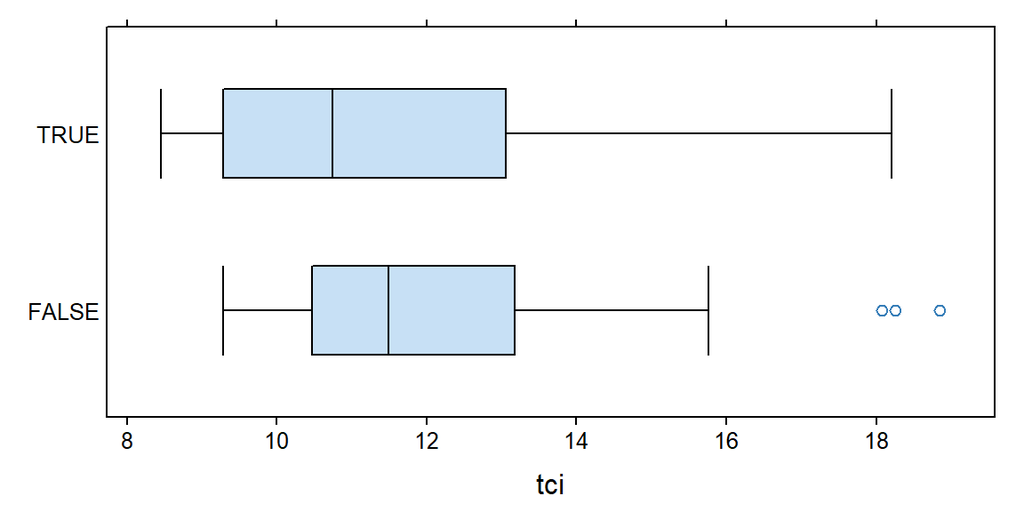

```r
bwplot(o.hz ~ tci, data=m, par.settings=tactile::tactile.theme())
```

## Investigate Influencial Obs

```r
# build prelim model, plot diagnostics
l <- lm(MAST ~ elev + solar + tci + o.hz, data=m)
summary(l)
```

```
##
## Call:
## lm(formula = MAST ~ elev + solar + tci + o.hz, data = m)
##
## Residuals:
##     Min      1Q  Median      3Q     Max
## -3.6490 -0.8006 -0.3764  0.9883  4.8795
##
## Coefficients:
##               Estimate Std. Error t value Pr(>|t|)
## (Intercept)  2.059e+01  2.079e+00   9.903 8.05e-12 ***
## elev        -5.772e-03  5.349e-04 -10.791 7.82e-13 ***
## solar        7.097e-05  2.885e-05   2.460 0.018823 *
## tci         -4.189e-01  1.030e-01  -4.069 0.000246 ***
## o.hzTRUE    -2.129e+00  5.895e-01  -3.611 0.000921 ***
## ---
## Signif. codes:  0 '***' 0.001 '**' 0.01 '*' 0.05 '.' 0.1 ' ' 1
##
## Residual standard error: 1.708 on 36 degrees of freedom
## Multiple R-squared:  0.7835, Adjusted R-squared:  0.7595
## F-statistic: 32.58 on 4 and 36 DF,  p-value: 1.645e-11
```

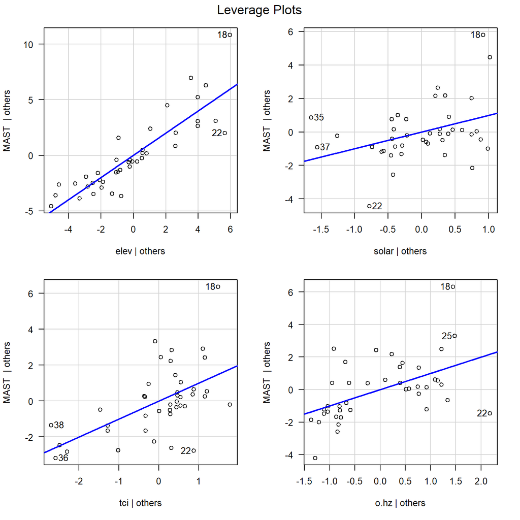

```r
leveragePlots(l, las=1)
```

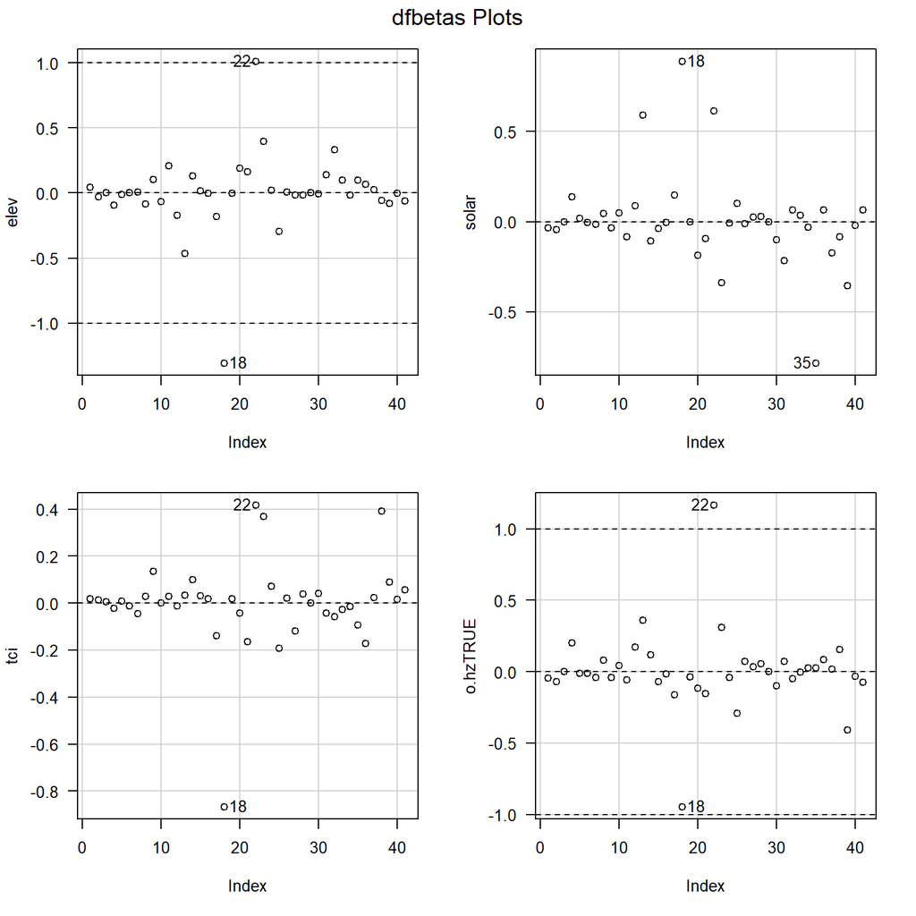

```r
# standardized dfbeta
dfbetasPlots(l, id.n=2, las=1)
```

```r
# ID outliers based on common metrics, and remove
out.row.names <- as.integer(attr(outlierTest(l, cutoff=0.05)$rstudent, 'names'))
# row names are not the same as row indexes in the presence of missing data!
out.idx <- which(row.names(m) %in% out.row.names)

# manully mark for removal from model
# out.idx <- c(18, 22)

# check
m[out.idx, ]
```

```
##            name mlra_sso user_site_id serial_number sensor_type sensor_depth      model project sid
## 18 yosemite_148    2-SON       790148      10136181    soiltemp           50 Hobo ProV2   CA790  95
##             start.date            end.date dslv days.of.data gap.index functional.yrs complete.yrs
## 18 1999-08-19 00:00:00 2018-09-13 00:00:00  543         1794       0.3              4            3
##     MAST Winter Summer     STR     elev    solar     tci o.hz.thick wgs84_longitude wgs84_latitude
## 18 19.03  11.56  26.22 thermic 1296.649 74197.04 10.0727          0          259317        4176038
##     o.hz
## 18 FALSE
```

```r
# save a copy and leave them out from original data
m.outliers <- m[out.idx, ]
m.sub <- m[-out.idx, ]
```

## Fit Model

```r
# setup labels for RMS plotting functions
label(m.sub$elev) <- 'Elevation (m)'
label(m.sub$solar) <- 'Ann. Beam Radiance (MJ/sq.m)'
label(m.sub$tci) <- 'Saga Wetness Index'
label(m.sub$o.hz.thick) <- 'O horizon thickness (cm)'
label(m.sub$o.hz) <- 'O horizon thickness > 1 cm'
label(m.sub$MAST) <- 'Mean Annual Soil Temperature (deg. C)'

# model with rms functions
dd <- datadist(m.sub)
options(datadist="dd")

# fit model, MAST is in deg C
(l <- ols(MAST ~ rcs(elev, 3) + solar + o.hz + tci, data=m.sub, x=TRUE, y=TRUE, weights = m.sub$complete.yrs / max(m.sub$complete.yrs)))
```

```
## Linear Regression Model
##
##  ols(formula = MAST ~ rcs(elev, 3) + solar + o.hz + tci, data = m.sub,
##      weights = m.sub$complete.yrs/max(m.sub$complete.yrs), x = TRUE,
##      y = TRUE)
##
##                  Model Likelihood    Discrimination
##                        Ratio Test           Indexes
##  Obs      40    LR chi2     75.81    R2       0.850
##  sigma0.9100    d.f.            5    R2 adj   0.828
##  d.f.     34    Pr(> chi2) 0.0000    g        3.569
##
##  Residuals
##
##      Min      1Q  Median      3Q     Max
##  -6.0381 -0.6775 -0.1691  0.3230  2.8148
##
##
##            Coef    S.E.   t     Pr(>|t|)
##  Intercept 24.9834 2.3684 10.55 <0.0001
##  elev      -0.0084 0.0011 -7.97 <0.0001
##  elev'      0.0031 0.0010  3.08 0.0041
##  solar      0.0000 0.0000  2.21 0.0339
##  o.hz=TRUE -1.5151 0.5197 -2.92 0.0062
##  tci       -0.3457 0.0870 -3.97 0.0003
##
```

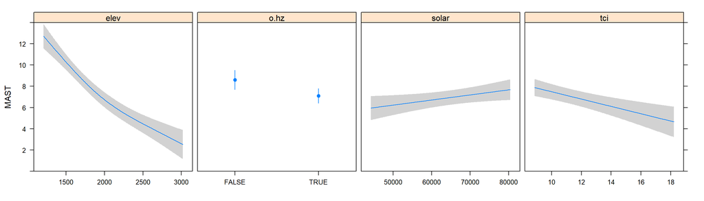

```r
# visual check: partial effects make sense
plot(Predict(l), as.table=TRUE, layout=c(4,1))
```

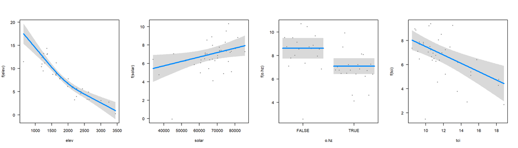

```r
# better visualization of partial effects + residuals
par(mfcol=c(1, 4))
visreg(l)
```

```r
## see
# Hmisc:::Function(l.ols)
```

## Examination of Residuals and Influential Observations

From the `residuals.ols` manual page:

- “ordinary” refers to the usual residual
- “score” is the matrix of score residuals (contributions to first derivative of log likelihood).
- “dfbeta” and “dfbetas” mean respectively the raw and normalized matrix of changes in regression coefficients after deleting in turn each observation. The coefficients are normalized by their standard errors.
- “hat” contains the leverages, diagonals of the “hat” matrix.
- dffit and dffits contain respectively the difference and normalized difference in predicted values when each observation is omitted. The S lm.influence function is used.
- “hscore”: the ordinary residuals are divided by one minus the corresponding hat matrix diagonal element to make residuals have equal variance.

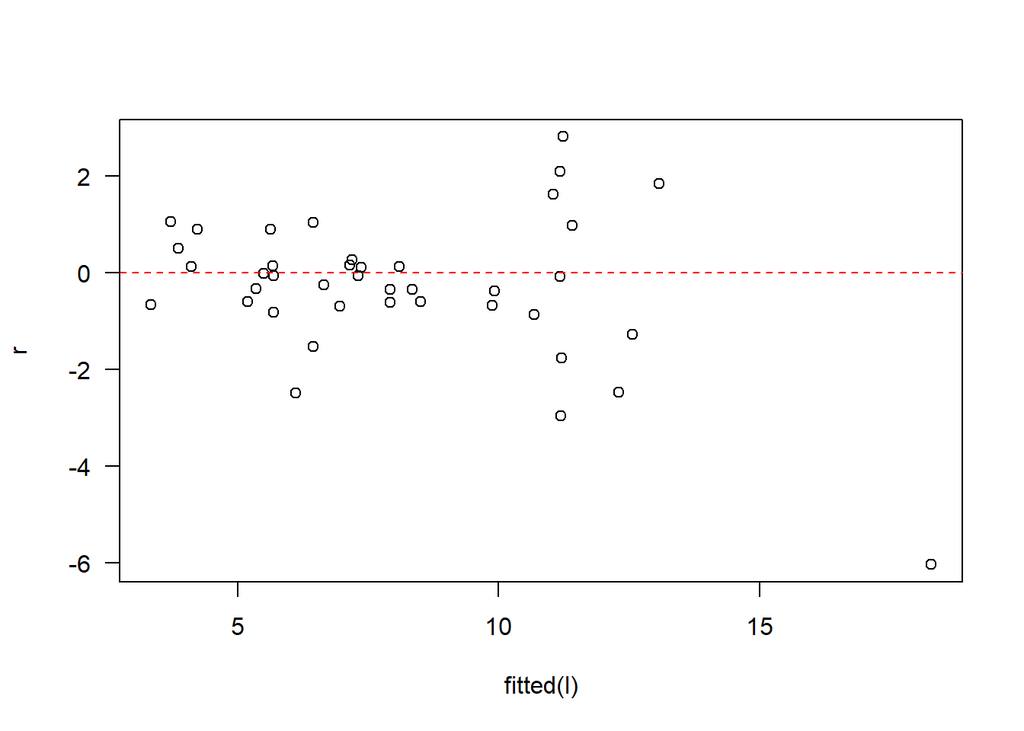

```r
# assumption of homogenaity: constant variance
r <- residuals(l, type = 'ordinary')
plot(r ~ fitted(l), las=1)
abline(h=0, lty=2, col='red')
```

```r
# cutoff: change of x-fraction standard errors after removal of an observation
show.influence(which.influence(l, cutoff = 0.5), m.sub)
```

```
##    Count       elev     solar   o.hz
## 13     3 *1350.7335 *76497.32 *TRUE
## 21     2 *1238.8474  67634.59  TRUE
## 22     1   641.3183  44613.13 *FALSE
## 32     1 *3250.6509  81657.76  FALSE
```

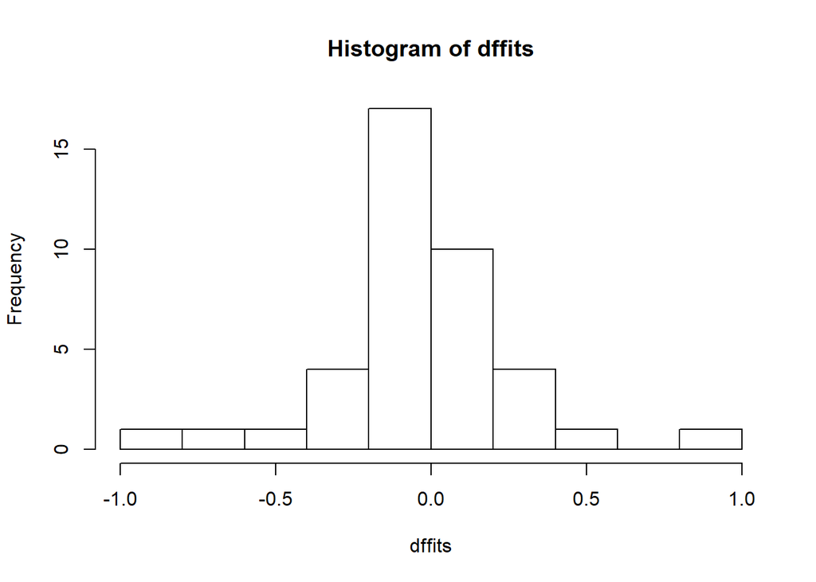

```r
# how can I interpret these?
dffits <- residuals(l, type = 'dffit')
hist(dffits)
```

```r
# dfbetas: then what?
dfb <- residuals(l, type = 'dfbetas')
head(dfb)
```

```
##              [,1]         [,2]         [,3]        [,4]         [,5]         [,6]
## [1,] -0.015786306  0.153396769 -0.143728336 -0.12976760 -0.197270183  0.057434763
## [2,]  0.068456579 -0.037134557  0.018953322 -0.05656430 -0.089890073  0.005002965
## [3,] -0.042036099  0.034634066 -0.029975925 -0.02246141 -0.007222181  0.076502959
## [4,]  0.003100744 -0.214154615  0.254637391  0.14283970  0.304791001 -0.005414164
## [5,] -0.003242441 -0.010879455  0.008655601  0.01441217 -0.006798787  0.004751018
## [6,]  0.048720519 -0.007329515  0.011833772 -0.01857143 -0.057870536 -0.070539160
```

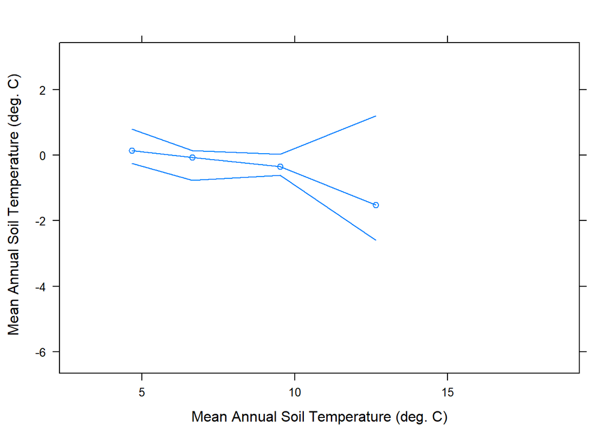

```r
# from section 7.4 Checking Distributional Assumptions (Harrell, 2001)
# whats up with the axis labels?
r <- resid(l)
xYplot(r ~ fitted(l), method='quantile')
```

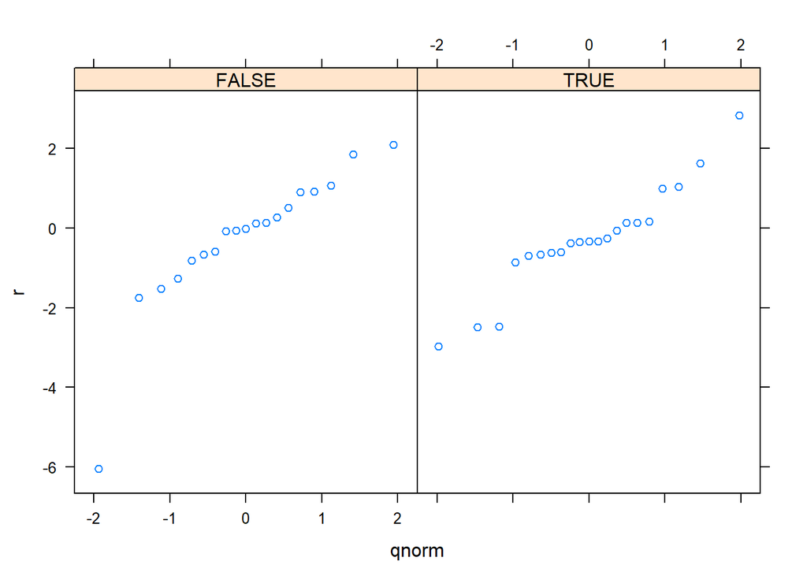

```r
# QQ plots stratified...
qqmath(~ r | m.sub$o.hz)
```

## Visual Evaluation of Model Fit

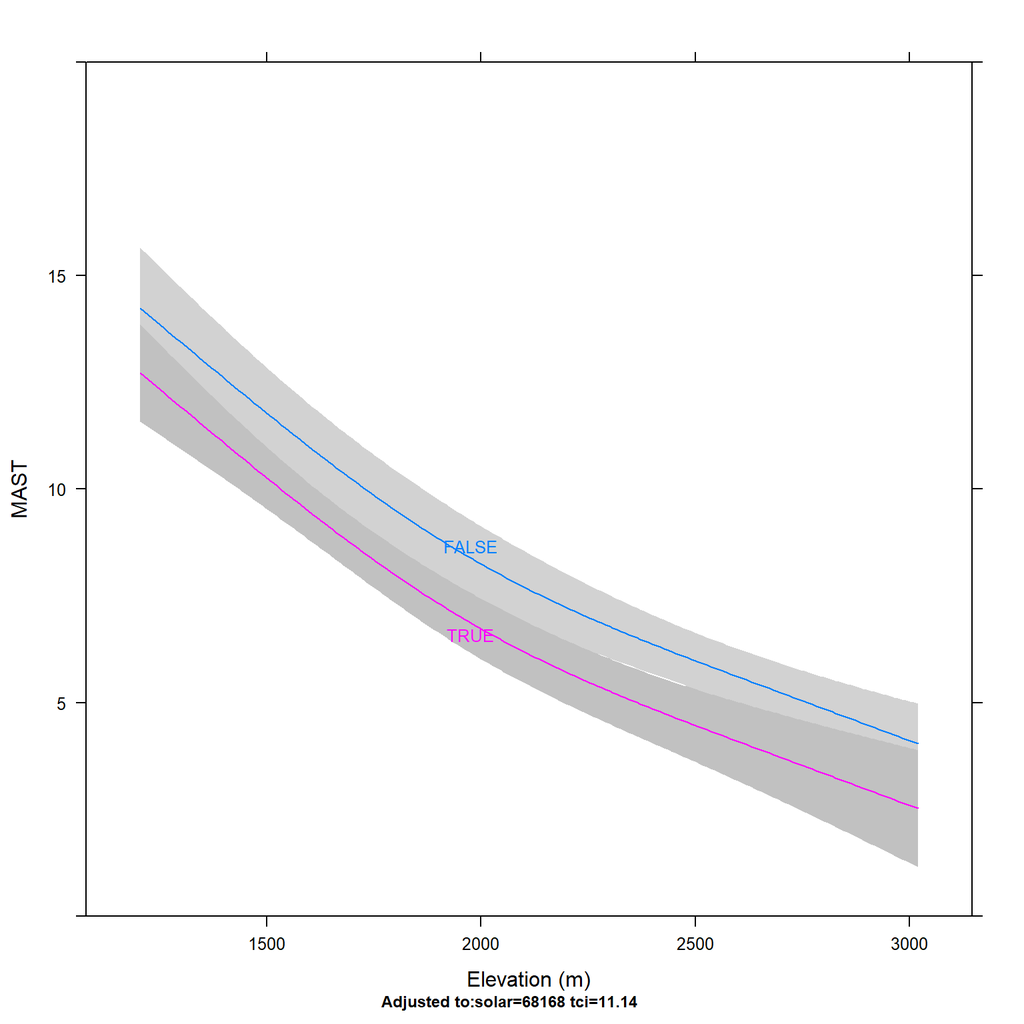

```r
# view slices of elevation partial effect at several O horizon thickness
plot(Predict(l, elev=NA, o.hz=c('FALSE', 'TRUE')))
```

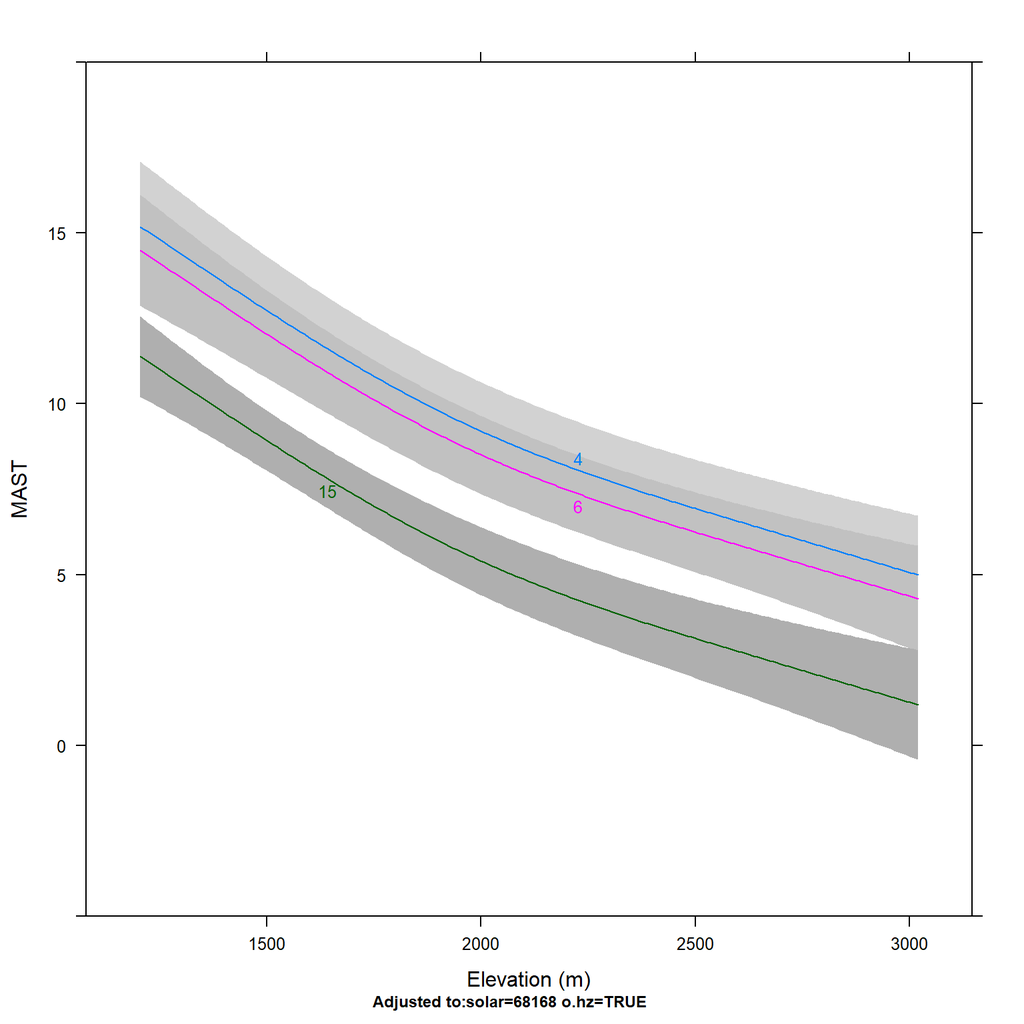

```r
plot(Predict(l, elev=NA, tci=c(4, 6, 15)))
```

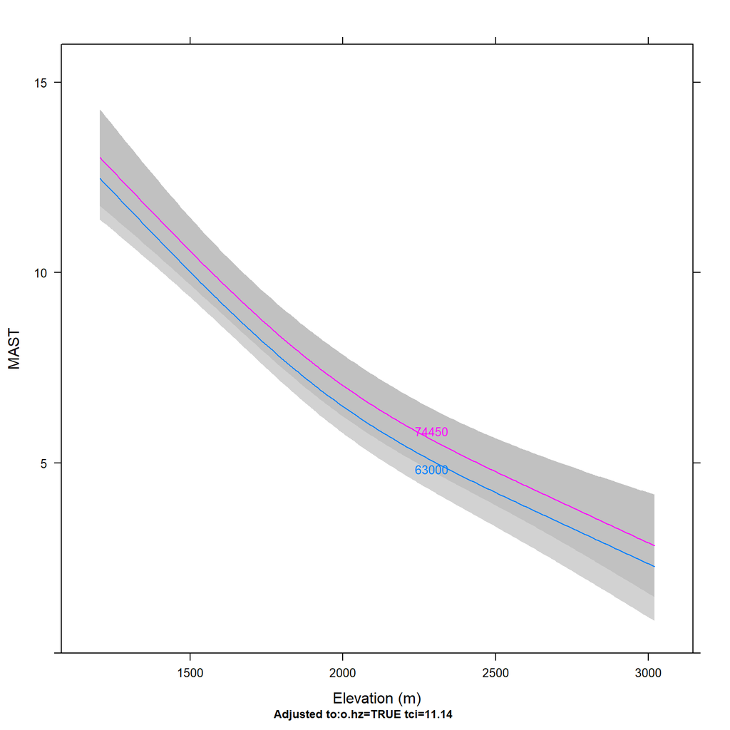

```r
plot(Predict(l, elev=NA, solar=c(63000, 74450)))
```

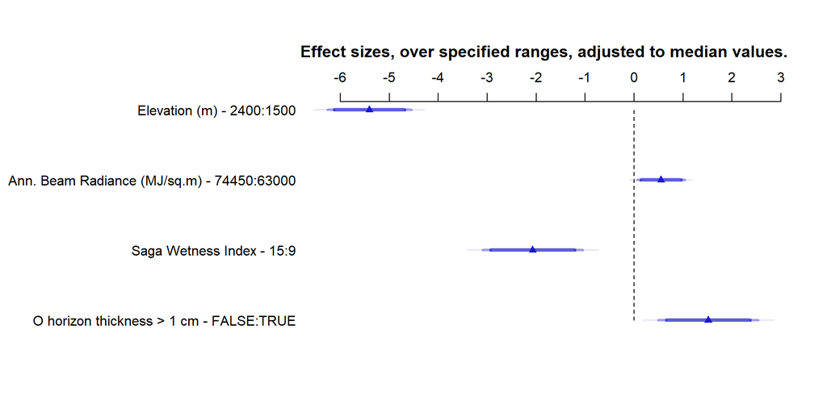

```r
# view effects over each IQR
plot(
  summary(l, vnames='labels',
          elev=c(1500, 2400),
          solar=c(63000, 74450),
          tci=c(9, 15),
          o.hz=c('FALSE', 'TRUE')
  ),
  cex=1, main='Effect sizes, over specified ranges, adjusted to median values.'
)
```

```r
# cross-validation

# diagnostics:
anova(l)
```

```
##                 Analysis of Variance          Response: MAST
##
##  Factor     d.f. Partial SS MS         F     P
##  elev        2   127.803896 63.9019479 77.16 <.0001
##   Nonlinear  1     7.867348  7.8673481  9.50 0.0041
##  solar       1     4.046126  4.0461264  4.89 0.0341
##  o.hz        1     7.039733  7.0397329  8.50 0.0063
##  tci         1    13.083003 13.0830035 15.80 0.0004
##  REGRESSION  5   154.533698 30.9067396 37.32 <.0001
##  ERROR      33    27.330201  0.8281879
```

```r
# since we are using both the rms and car packages, need to specify which vif()
rms::vif(l)
```

```
##      elev     elev'     solar o.hz=TRUE       tci
##  9.648045  9.547506  1.498396  1.704269  1.247234
```

```r
# eval mean-absolute-error (original units of data set)
(mast.MAE <- round(mean(abs(m.sub$MAST - predict(l, m.sub)), na.rm=TRUE), 2))
```

```
## [1] 1.02
```

```r
# save fitted / residuals to point data
m.sub$resid <- resid(l)
m.sub$fitted <- fitted(l)
m.sub$r_f <- with(m.sub, abs(resid)/fitted)

# # prepare point data spatial output with model diagnostics
# s <- h
# s@data <- s@data[, 'site_name', drop=FALSE]
# s@data <- join(s@data, m, by='site_name', type='left')
```

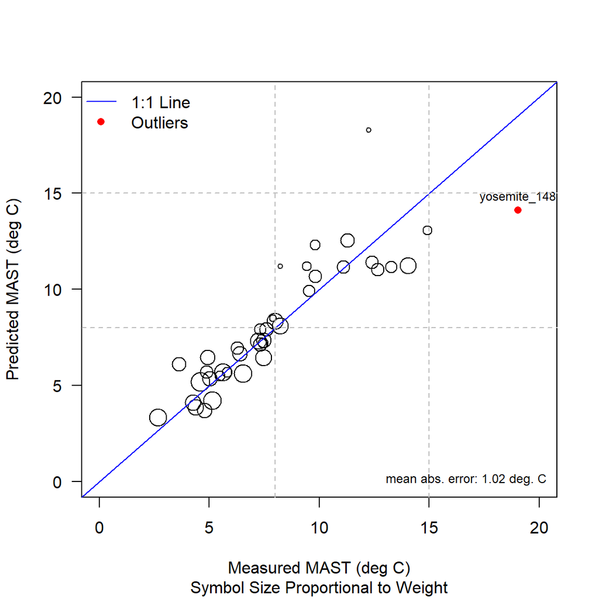

```r
plot(predict(l, m.sub) ~ m.sub$MAST, ylab='Predicted MAST (deg C)', xlab='Measured MAST (deg C)', xlim=c(0,20), ylim=c(0,20), las=1, cex=sqrt(m.sub$complete.yrs/2), sub='Symbol Size Proportional to Weight')
points(predict(l, m.outliers) ~ m.outliers$MAST, col='red', pch=16)
text(m.outliers$MAST, predict(l, m.outliers), labels=m.outliers$name, pos=3, cex=0.75)
abline(0, 1, col='blue')
abline(v=c(8, 15), h=c(8, 15), lty=2, col='grey')
legend('topleft', legend=c('1:1 Line', 'Outliers'), lty=c(1, NA), pch=c(NA, 16), col=c('blue', 'red'), bty='n')
legend('bottomright', legend=paste('mean abs. error:', mast.MAE, 'deg. C'), cex=0.75, bty='n', inset=0.01)
```

## Estimate MAST at Each Grid Cell

```r
# model SE requires a helper function
predfun <- function(model, data) { cbind(se=predict(model, data, se.fit=TRUE)$se.fit) }

# since we don't have a raster depicting O horizon thickness, we will have to simulate it
# simplest approach is to make several predictions at fixed O hz thickness

# iterate over possible set of O hz thickness: from summary stats
o.hz.thick <- c(0, 2, 4)
for(i in o.hz.thick) {
  # make a fake O horizon thickness raster
  r.o.hz <- raster(r.stack)
  r.o.hz <- setValues(r.o.hz, values = i)
  names(r.o.hz) <- 'o.hz.thick'
  # make new stack
  r.stack.pred <- stack(r.stack, r.o.hz)

  # make file names
  f.pred <- paste0('spatial_data/mast-model-', i)
  f.pred.se <- paste0('spatial_data/mast-model-se-', i)

  # MAST model: estimates and SE
  predict(r.stack.pred, l, progress='text', filename=f.pred, datatype='FLT4S', format='GTiff', overwrite=TRUE)
  predict(r.stack.pred, l, fun=predfun, progress='text', filename=f.pred.se, datatype='FLT4S', format='GTiff', overwrite=TRUE)
}

# save model diagnostics as SHP
# can't convert labeled columns, have to do manually
s$elev <- as.numeric(s$elev)
s$solar <- as.numeric(s$solar)
s$tci <- as.numeric(s$tci)
s$o.hz.thick <- as.numeric(s$o.hz.thick)
s$MAST <- as.numeric(s$MAST)
s$resid <- as.numeric(s$resid)
s$fitted <- as.numeric(s$fitted)
s$r_f <- as.numeric(s$r_f)
writeOGR(s, dsn='spatial_data', layer='point-data', driver='ESRI Shapefile', overwrite_layer=TRUE)
```